# Your Digest for Saturday, Aug 05, 2023 11:59 PM

# Angina

## Overview of management of Angina

We're talking about "Chronic coronary syndrome" = "Stable ischemic heart disease".  
**Angina equivalents** = dyspnoea on exertion, + others. #TODO

### Goals of care:

- relieve symptoms -> [[#antianginal medications]]
- Preventing disease progression
  - Medication - aspirin
  - Risk factor management - lipid lowering therapy, smoking cessation, BP control, weight loss, optimal DM management, regular exercise, stress reduction etc.
- Prevent future cardiac events (like ACS, death)

#### Place for angiography and revascularization:

- patient has symptoms that interfere with everyday functioning *despite maximum medical therapy*
- Non-invasive testing suggests that a large amount of viable myocardium is at risk.

## Antianginal medications

3 main classes of medications

1. Beta blockers - see [[#Beta blockers]] below
   1. First line anti anginal medications; Initial step in angina management is "beta blocker montherapy." Beta blockers are the only antianginals proven to **reduced reinfarction** and **reduce mortablity**.
   2. All are equally effective.
   3. Mechanism: reduce heart rate and contractility -> reduced oxygen demand -> therefore delay the onset of angina during exercise. Also reduced LV *wall stress*by their antihypertensive action.
   4. Beta blockers reduce mortality when it comes to **secondary prevention** but technically, there is no evidence that they prevent the first MI in a patient with angina.
   5. Contraindicated in prinz-metal angina; unopposed alpha action may exacerbate coronary vasospasm.
2. CCBs
   1. Can use as monotherapy when beta blockers are contraindicated.
   2. or as combination with beta blockers.
   3. contraindicated in LV dysfunction.
   4. diltiazem and verapamil (nondihyropyridine) or amlopidine are preferred.
   5. Mechanism: Coronary and peripheral vasodilation and reduced contractility.
3. Long acting nitrates
   1. Used as mono therapy or combination with beta blockers.
   2. Tolerance is a problem for long term therapy. (due to decreased vascular sensitivity to nitrates)
   3. Mechanism: They dilate systemic arteries, systemic veins and coronary arteries. Venodilation >> arterial dilation. (increased bioavailability to venous smooth muscle) Therefore, the main antianginal effect is due to venodilation -> reduced preload -> reduced ventricular wall stress -> reduced oxygen deman -> antianginal effect.
4. Newer addition - ranolazine - late sodium channel blocker.

Note: Ivabradine, despite being a heart rate lowering drug is **NOT** given as an antianginal.

**Combination therapy** is commonplace for antianginal medication.

## Beta blocker pharmacology

There are 3 types of beta receptors.  
B1 - heart  
B2 - lungs  
B3 - adipose tissue

Cardioselective beta blockers are B1 selective. Non selective blockers block both. Selective blockers may block B2 at high doses.  
Cardioselective - Bisoprolol, atenolol, Metoprolol + esmolol, bisoprolol.  
Alpha-adrenergic blocking activity - lebetalol and carvedilol block *beta* and **alpha** receptors. They reduce coronary and peripheral vascular resistance.

> All beta blockers appear equally effective in the treatment of stable angina.

Two groups of beta blockers based on metabolism

| Eliminated by hepatic metabolism | Eliminated unchanged by kidney |
| --- | --- |
| Lipid soluble | water soluble |
| High CNS penetration (more SE) | poor CNS penetration |
| short half lives | longer half lives |
| variable bioavailability | less variable |
| completely absorbed in small intestine | incompletely absorbed by the gut |
| propranolol and metoprolol | Atenolol, sotalol |

> [!TIP] HeMP SAK

[figure not shown]

> hepatic - Metoprolol and propronolol  
> SAK - Sotalol and atenolol - Kidney

# Goodpasture's syndrome

#2022SBR Q6

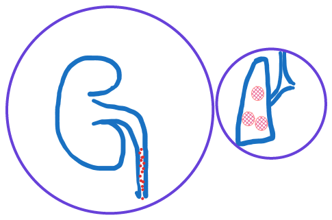

> [!WARNING] Importance of quick diagnosis  
> Quick diagnosis makes for a better outcome as delay leads to renal damage which in turn leads to low chance of renal recovery. .

## Background / context

Immune complex mediated, small vessel vasculitis.  
Prototype disease of "*diffuse alveolar haemorrhage syndromes*".

- These can be either **with pathologic capillaritis or without** ->[[diffuseAlveolarHaemorrhageSyndromes.png]] [Source](https://www.ncbi.nlm.nih.gov/pmc/articles/PMC2658676/)
- Diffuse alveolar haemorrhage syndromes consist of a triad of haemoptysis, anaemia and diffuse pulmonary infiltrates.

## Pathogenesis / pathology of goodpasture's syndrome

Goodpasture's syndrome has a triad of features:

1. Circulating antibodies against intrinsic antigen of basement membranes of **lung** and **kidney**. Same antigen is expressed in the lung and the kidney.
2. Pulmonary haemorrhage
3. Glomerulonephritis - *proliferative*, rapidly progressive glomerulonephritis with *crescent formation*
- Lung Histology: focal necrosis of alveolar walls associated with intra-alveolar haemorrhages. Macrophages will contain haemosiderin, engulfed from previous episodes.

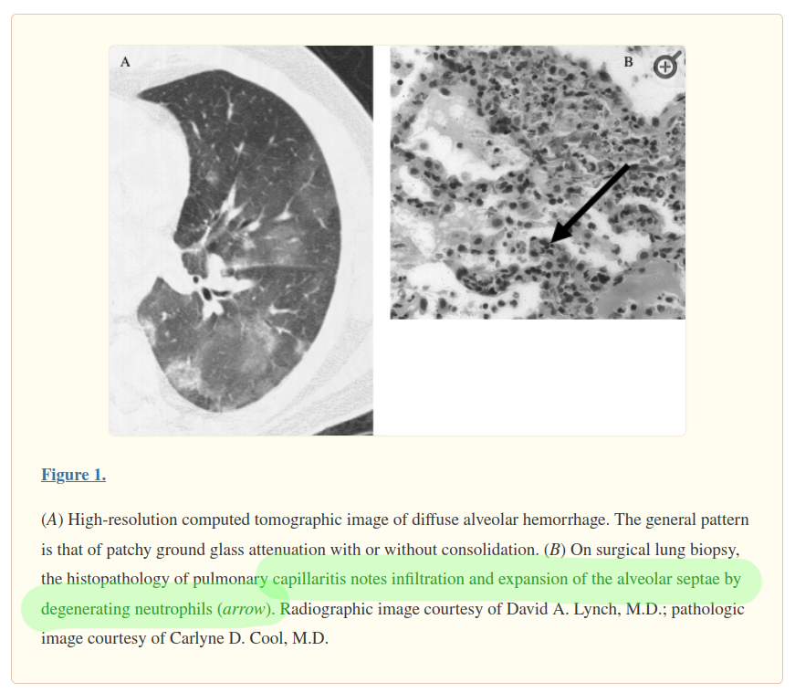

- Histology : kidney - characteristic **linear pattern** of *immunoglobulin deposition*.

## Clinical presentation of Goodpasture's syndrome

Two age peaks : **30 years** -> more likely to present with pulmonary haemorrhage;  
> **50 years** : more likely to present with isolated glomerulonephritis.

>90% present with features of RPGN; (hematuria, proteinuria, cellular casts, kidney function impairment). A large percentage have simultaneous pumonary haemorrhage. A few present with isolated pulmonary haemorrhage. Prodrome of systemic symptoms is short.

> [!INFO] Nephritic sediment  
> nephritic sediment is characterized by dysmorphic red cells (including acanthocytes), white cells, and red cell and granular casts.

Respiratory symptoms may precede glomerulonephritis by weeks to months.  
Mild to life threatening haemopsytis.

Carbon monoxide gas transfer is **increased** (increased blood in the alveoli [[Respiratory medicine MCQ discussion#Mechanism of DLCO]])

**Diagnosis** : serum for anti-GBM antibodies and renal biopsy.  
**Treatment**: remove the antibodies by plasmapheresis and prevent recurrent with immunosuppression (prednisilon / cyclophosphamide)  
**Prognosis:** Recurrence is rare; earlier diagnosis -> less severe renal failure -> recovery; late diagnosis or significant renal impairment at presentation -> chronic kidney disease and dialysis requirement.

# Management of TIA / ischemic stroke

#2022SBR Q21

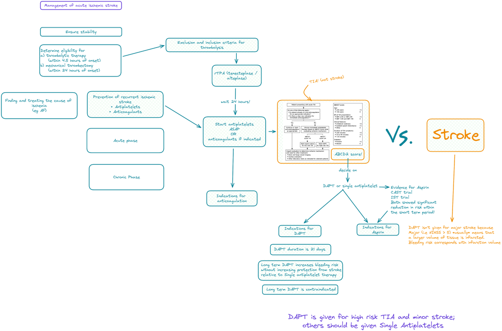

# Angina

## Overview of management of Angina

We're talking about "Chronic coronary syndrome" = "Stable ischemic heart disease".

### Goals of care:

- relieve symptoms -> [[#antianginal medications]]
- Preventing disease progression
  - Medication - aspirin
  - Risk factor management - lipid lowering therapy, smoking cessation, BP control, weight loss, optimal DM management, regular exercise, stress reduction etc.
- Prevent future cardiac events (like ACS, death)

#### Place for angiography and revascularization:

- patient has symptoms that interfere with everyday functioning *despite maximum medical therapy*
- Non-invasive testing suggests that a large amount of viable myocardium is at risk.

## Antianginal medications

3 main classes of medications

1. Beta blockers - see [[#Beta blockers]] below
   1. First line anti anginal medications; Initial step in angina management is "beta blocker montherapy." Beta blockers are the only antianginals proven to **reduced reinfarction** and **reduce mortablity**.
   2. All are equally effective.
   3. Mechanism: reduce heart rate and contractility -> reduced oxygen demand -> therefore delay the onset of angina during exercise. Also reduced LV *wall stress*by their antihypertensive action.
   4. Beta blockers reduce mortality when it comes to **secondary prevention** but technically, there is no evidence that they prevent the first MI in a patient with angina.
   5. Contraindicated in prinz-metal angina; unopposed alpha action may exacerbate coronary vasospasm.
2. CCBs
   1. Can use as monotherapy when beta blockers are contraindicated.
   2. or as combination with beta blockers.
   3. contraindicated in LV dysfunction.
   4. diltiazem and verapamil (nondihyropyridine) or amlopidine are preferred.
   5. Mechanism: Coronary and peripheral vasodilation and reduced contractility.
3. Long acting nitrates
   1. Used as mono therapy or combination with beta blockers.
   2. Tolerance is a problem for long term therapy. (due to decreased vascular sensitivity to nitrates)
   3. Mechanism: They dilate systemic arteries, systemic veins and coronary arteries. Venodilation >> arterial dilation. (increased bioavailability to venous smooth muscle) Therefore, the main antianginal effect is due to venodilation -> reduced preload -> reduced ventricular wall stress -> reduced oxygen deman -> antianginal effect.
4. Newer addition - ranolazine

**Combination therapy** is commonplace for antianginal medication.  
**Angina equivalents** = dyspnoea on exertion, + others. #TODO

## Beta blocker pharmacology

There are 3 types of beta receptors.  
B1 - heart  
B2 - lungs  
B3 - adipose tissue

Cardioselective beta blockers are B1 selective. Non selective blockers block both. Selective blockers may block B2 at high doses.  
Cardioselective - Bisoprolol, atenolol, Metoprolol + esmolol, bisoprolol.  
Alpha-adrenergic blocking activity - lebetalol and carvedilol block *beta* and **alpha** receptors. They reduce coronary and peripheral vascular resistance.

> All beta blockers appear equally effective in the treatment of stable angina.

[figure not shown]

1. *Small vessel - **ANCA Associated vasculitides** - GPA / Wegener's, MPA, EGPA /Churgg Strauss*  
1. Good pastures  
2. Henoch-Schonlein purpura  
3. Behcet' disease  
4. IgA nephropathy.